# CNVassoc: Association analysis of CNV data and imputed SNPs

Isaac Subirana and Juan R González

CIBER Epidemiology and Public Health (CIBERESP)  
IMIM-Parc de Salut Mar  
Barcelona Institute for Global Health (ISGlobal)

isubirana@imim.es

2 abril 2019

#### Package

CNVassoc 2.4

# 1 Introduction

*CNVassoc* allows users to perform association analysis between CNVs and disease incorporating uncertainty of CNV genotype. This document provides an overview on the usage of the *CNVassoc* package. For more detailed information on the model and assumption please refer to article (Gonzalez et al. 2009) and its supplementary material. We illustrate how to analyze CNV data by using some real data sets. The first data set belongs to a case-control study where peak intensities from MLPA assays were obtained for two different genes. The second example corresponds to the Neve dataset (Neve et al. 2006) that is available at Bioconductor. The data consists of 50 CGH arrays of 1MB resolution for patients diagnosed with breast cancer. All datasets are available directly from the *CNVassoc* package. Finally, we show examples with Poisson and Weibull-distributed phenotypes.

Start by loading the package *CNVassoc*:

```r
library(CNVassoc)
```

and some required libraries

```r
library(knitr)
```

# 2 CNV from a single probe

## 2.1 The data

In order to illustrate how to assess association between CNV and disease, we use a data set including 360 cases and 291 controls. Data is to be published soon as described in (Gonzalez et al. 2009). The data contains peaks intensities for two genes arising from an MLPA assay. Note that Illumina or Affymetrix data, where log2 ratios are available instead of peak intensities, can be analyzed in the same way as we are illustrating.

The MLPA data set contains case control status as well as two simulated covariates (`quanti` and `cov`) that have been generated for illustrative purposes (e.g., association between a quantitative trait and CNV or how to adjust for covariates). To load the MLPA data just type

```r
data(dataMLPA)
head(dataMLPA)
```

```
    id casco Gene1     Gene2 PCR.Gene1 PCR.Gene2 quanti   cov
1 H238     1  0.51 0.5385080        wt        wt  -0.61 10.83
2 H238     1  0.45 0.6392029        wt        wt  -0.13 10.69
3 H239     1  0.00 0.4831572       del        wt  -0.57  9.63
4 H239     1  0.00 0.4640072       del        wt  -1.40  9.87
5 H276     1  0.00 0.0000000       del       del   0.83 10.25
6 H276     1  0.00 0.0000000       del       del  -2.07 10.40
```

First, we look at the distribution of peak intensities for each of the two genes analyzed: see Figure 1.

Figure 1 shows the signals for Gene 1 and Gene 2. For both genes it is clear that there are 3 clusters corresponding to 0, 1 and 2 copies. However, the three peaks for Gene 2 are not so well separated as those of Gene 1 (the underlying distributions overlap much more). This fact leads to more uncertainty when inferring the copy number status for each individual. This will be illustrated in the next section.

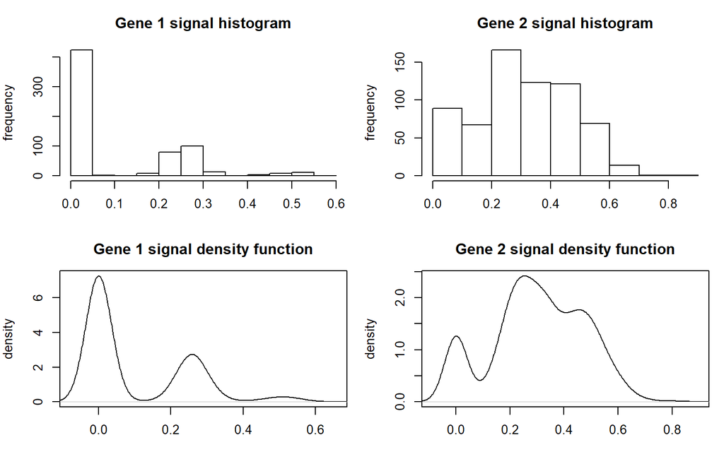

Figure 1: Signal distributions for Gene 1 and Gene 2

```r
par(mfrow=c(2,2),mar=c(3,4,3,1))
hist(dataMLPA$Gene1,main="Gene 1 signal histogram",xlab="",ylab="frequency")
hist(dataMLPA$Gene2,main="Gene 2 signal histogram",xlab="",ylab="frequency")
par(xaxs="i")
plot(density(dataMLPA$Gene1),main="Gene 1 signal density function",xlab="",ylab="density")
plot(density(dataMLPA$Gene2),main="Gene 2 signal density function",xlab="",ylab="density")
```

In the *CNVassoc* package, a function called `plotSignal` has been implemented to plot the peak intensities for a gene. To illustrate this, a plot of the intensities of Gene 2 for each individual, distinguishing between cases and controls, can be performed by typing (see figure 2)

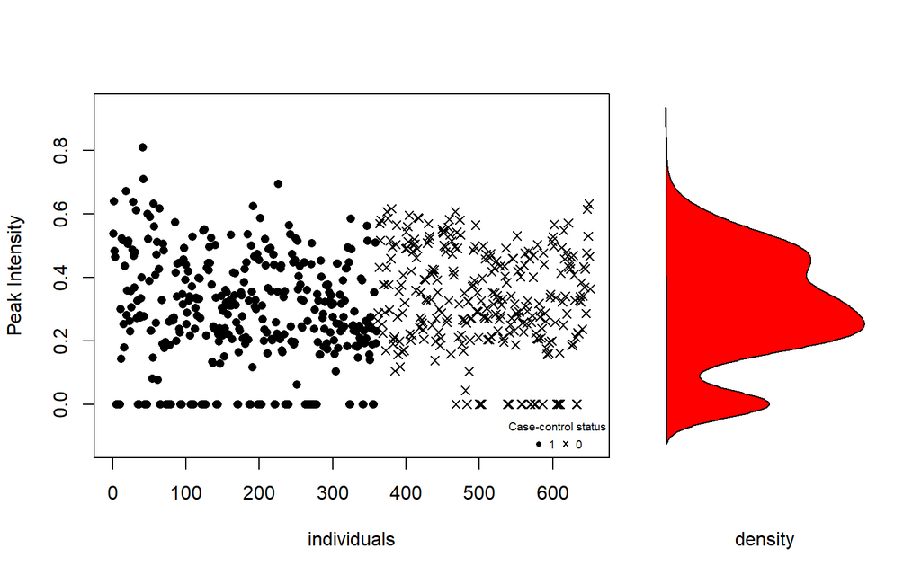

Figure 2: Signal distribution for Gene 2 using plotSignal function

```r
plotSignal(dataMLPA$Gene2,case.control=dataMLPA$casco)
```

or, similarly but correlating the peak intensities with a quantitative phenotype (see figure 3) type

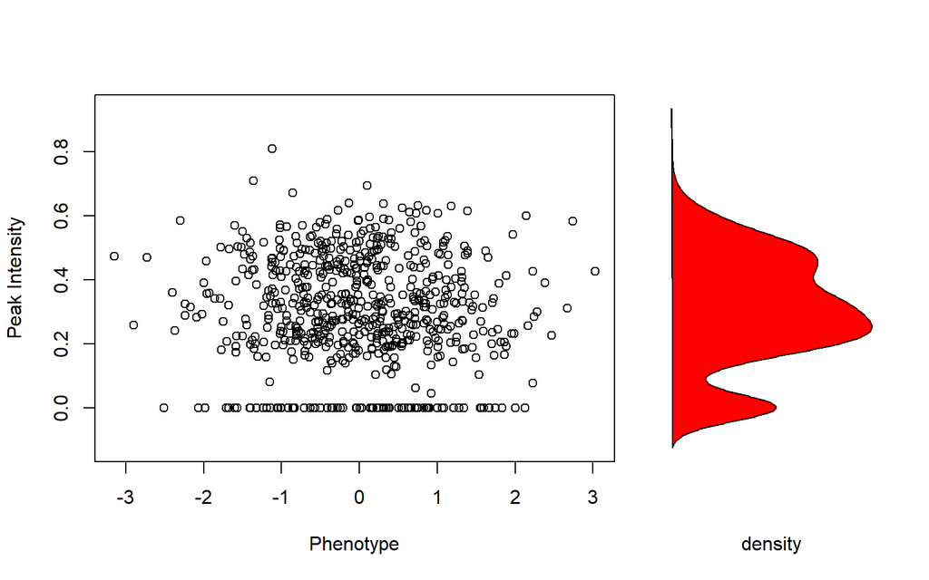

Figure 3: Signal distribution for Gene 2 using plotSignal

```r
plotSignal(dataMLPA$Gene2, case.control = dataMLPA$quanti)
```

In figure 3, the quantitative phenotype is plotted on the x-axis, instead of distinguishing points by shape, as in figure 2.

Also, it is possible to specify the number of cutoff points and place them interactively via `locator` on the previous plot, in order to infer the copy number status in a naive way. (More sophisticated ways of inferring copy number status will be dealt with in subsequent sections). To place 2 cutoff points, thereby defining 3 copy number status values or clusters, (note use of argument `n=2`) and store them as `cutpoints`:

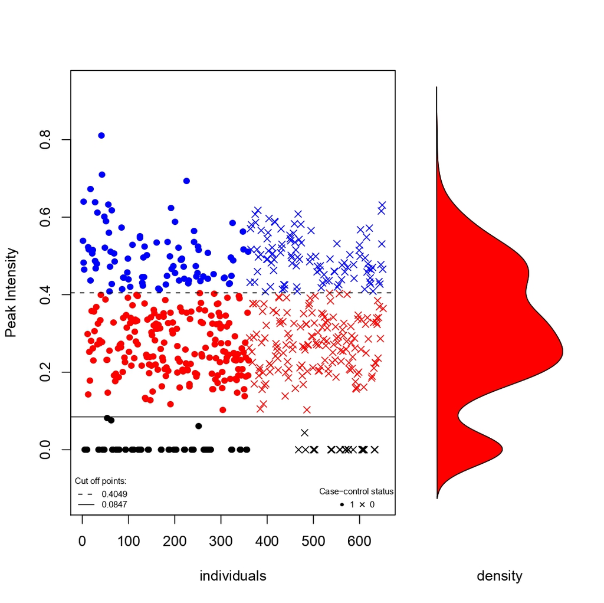

Figure 4: Signal distribution for Gene 2 using plotSignal once cutoff points have been set with locator

```r
cutpoints <- plotSignal(dataMLPA$Gene2, case.control = dataMLPA$casco, n = 2)
```

The plot generated in figure 4 is similar to figure 2, but using colours to distinguish copy number status values inferred from the cutoff points.

In this example, the cutoff points have been placed at:

```r
cutpoints
```

```
[1] 0.08470221 0.40485249
```

These stored cutoff points will be used in the following sections.

## 2.2 Inferring copy number status from signal data}

### 2.2.1 From univariate signal intensity

The `cnv` function is used to infer the copy number status for each subject using the quantitative signal for an individual probe. This signal can be obtained from any platform (MLPA, Illumina, …).

This function assumes a normal mixture model as other authors have proposed in the context of aCGH (Picard et al. 2007, Wiel et al. (2007)). It should be pointed out that in some instances, the intensity distributions (see Gene 1 in Figure 1) for a null allele are expected to be equal to 0. Due to experimental noise these intensities can deviate slightly from this theoretical value. For these cases, the normal mixture model fails because the underlying distribution of individuals with 0 copies is not normal. In these situations we fit a modified mixture model (see (Gonzalez et al. 2009) for further details).

Figure 1 presents two different scenarios. For Gene 1 there are clearly three different status values, but for Gene 2 the situation is not so clear.

Function `cnv` provides various arguments to cope with all these issues. The calling for Gene 1 can be done by executing

```r
CNV.1 <- cnv(x = dataMLPA$Gene1, threshold.0 = 0.06, num.class = 3, mix.method = "mixdist")
```

The argument `threshold.0 = 0.06` indicates that individuals with peak intensities lower than 0.06 will have 0 copies. Since there are three underlying copy number status values, we set argument `num.class` to 3. Argument `mix.method` indicates what algorithm to use in estimating the normal mixture model. `"mixdist"` uses a combination of a Newton-type method and the EM algorithm implemented in the *mixdist* library, while *mclust* uses the EM algorithm implemented in the `Mclust` library.

When the exact number of components for the mixture model is unknown (which may be the case for Gene 2), the function uses the Bayesian Information Criteria (BIC) to select the number of components. This is performed when the argument `num.class` is missing. In this case the function estimates the mixture model admitting from 2 up to 6 copy number status values.

```r
CNV.2 <- cnv(x = dataMLPA$Gene2, threshold.0 = 0.01, mix.method = "mixdist")
```

As we can see, the best model has a copy number status of 3. This result, obtained by using BIC, is as expected because we already know that this gene has 0, 1 and 2 copies (see (Gonzalez et al. 2009)).

### 2.2.2 From other algorithms

The result of applying function `cnv` is an object of class `cnv` that, among other things, contains the posterior probabilities matrix for each individual. This information is then used in the association analysis where the uncertainty is taken into account. Posterior probabilities from any other calling algorithms can also be encapsulated in a `cnv` object to be further used in the analysis.

To illustrate this, we will use the posterior probability matrix that has been computed when inferring copy number for Gene 2 by using the normal mixture model. This information is saved as an attribute for an object of class `cnv`. A function called `getProbs` has been implemented to simplify accessing this attribute. Thus the probability matrix can be saved in an object `probs.2` like this:

```r
probs.2 <- getProbs(CNV.2)
```

Imagine that `probs.2` contains posterior probabilities obtained from some calling algorithm such as CANARY (from `PLINK`) or *GCHcall* (this will be further illustrated in Section 3. In this case, we create the object of class `cnv` that will be used in the association step by typing

```r
CNV.2probs <- cnv(probs.2)
```

### 2.2.3 From predetermined thresholds

Inferring copy number status for Gene 2 from previously specified threshold points (stored in vector `cutpoints`) can be done using the same `cnv` function but setting the argument `cutoffs` to `cutpoints`.

```r
CNV.2th <- cnv(x = dataMLPA$Gene2, cutoffs = cutpoints)
```

Now, the inferred copy number object `CNV.2th` contains the same information as it would if it had been created directly from probabilities.

## 2.3 Summarizing information

We have implemented two generic functions for an object of class `cnv`. The generic `print` function gives the results on inferred copy number status. It includes the means, variances and proportions of copy number clusters as well as the p value corresponding to the goodness-of-fit test for the selected number of classes.

```r
CNV.1
```

```
Inferred copy number variant by a quantitative signal
   Method: function mix {package: mixdist}

-. Number of individuals: 651
-. Copies 0, 1, 2
-. Estimated means: 0, 0.2543, 0.4958
-. Estimated variances: 0, 9e-04, 0.0012
-. Estimated proportions: 0.6544, 0.3088, 0.0369
-. Goodness-of-fit test: p-value= 0.6615318
```

and for Gene 2

```r
CNV.2
```

```
Inferred copy number variant by a quantitative signal
   Method: function mix {package: mixdist}

-. Number of individuals: 651
-. Copies 0, 1, 2
-. Estimated means: 0, 0.2435, 0.4469
-. Estimated variances: 0, 0.0041, 0.0095
-. Estimated proportions: 0.1306, 0.4187, 0.4507
-. Goodness-of-fit test: p-value= 0.4887659


-. Note: number of classes has been selected using the best BIC
```

This report differs slightly when the object was created from only posterior probabilities:

```r
CNV.2probs
```

```
-. Copy number variant
   Input data: called probabilities
-. Number of individuals: 651
-. Copies 0, 1, 2
-. Estimated proportions: 0.1306, 0.4187, 0.4507
```

Figure 5 shows the result of invoking the generic `plot` function on these objects.

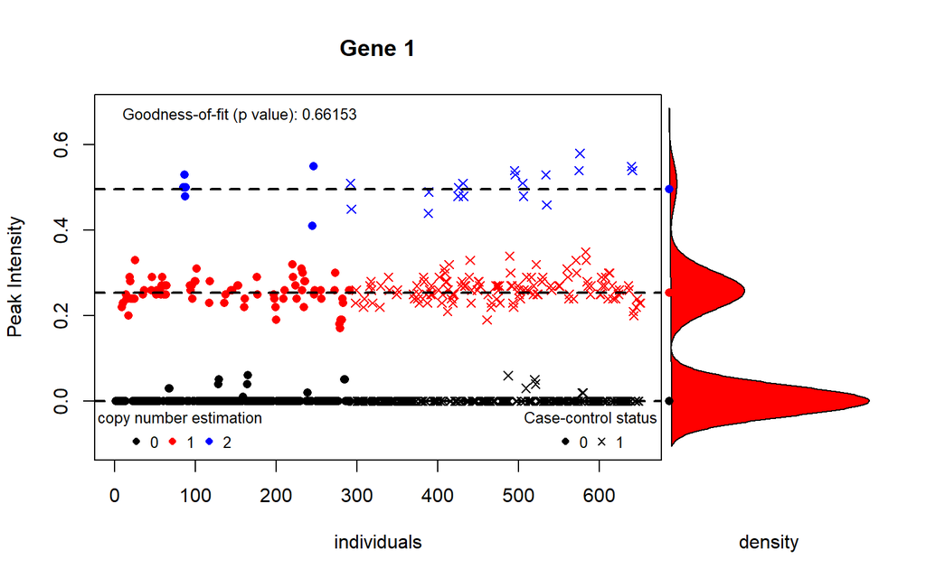

Figure 5: Signal distribution by case control, and inferred number of copies

```r
plot(CNV.1, case.control = dataMLPA$casco, main = "Gene 1")
```

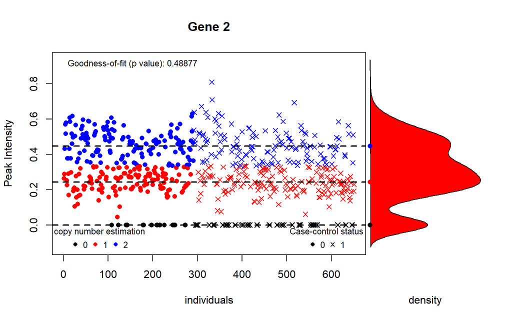

Figure 5: Signal distribution by case control, and inferred number of copies

```r
plot(CNV.2, case.control = dataMLPA$casco, main = "Gene 2")
```

In figure 5 the signal is coloured by the inferred (most probable) copy number, while cases and controls are distinguished by shape. This last option is specified by the argument `case.control`. On the right side of the plot, a density function of signal distribution is drawn. The p-value of goodness-of-fit test is the same as this described in the beginning of this section. It indicates whether the assumed normal mixture model (with a given number of components) is correct or not. Notice that for both genes the intensity data fits our the model well (goodness-of-fit p-values > 0.1).

The action of `plot` when only posterior probabilities are available gives a different result (Figure 6). Two barplots are created for cases and controls (when argument `case.control` is used). Both are split by the copy number frequency.

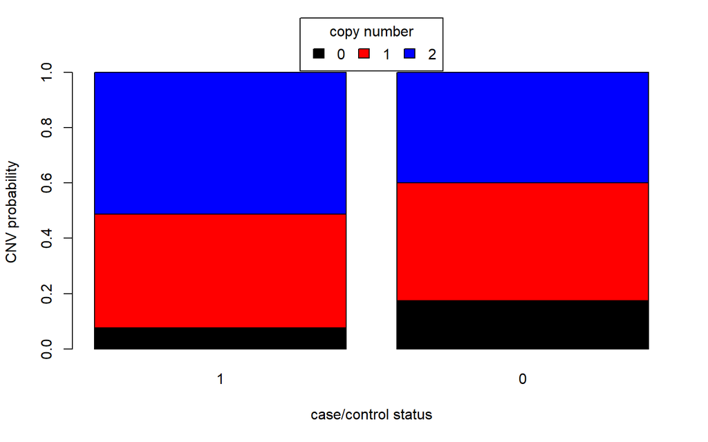

```r
plot(CNV.2probs, case.control=dataMLPA$casco)
```

## 2.4 Measuring uncertainty in inferring copy number status

The function `getQualityScore` uses information from an object of class `cnv` to compute a value that indicates how much the underlying copy number distribution (peak intensities) are mixed or overlapped. The more separated these peaks are (less uncertainty), the larger the quality score is.

Three measures of uncertainty are currently implemented. The first one is the same as that defined in the *CNVtools* package, the second is the estimated probabilty of good classification (PGC), and the third is defined as the the proportion of individuals with a confidence score (described in (Korn et al. 2008)) bigger than 0.1.

To choose PGC method type

```r
CNVassoc::getQualityScore(CNV.1, type = "class")
```

```
--Probability of good classification: 0.9999618
```

```r
CNVassoc::getQualityScore(CNV.2, type = "class")
```

```
--Probability of good classification: 0.9102022
```

To choose the measure defined in the *CNVtools* package:

```r
CNVassoc::getQualityScore(CNV.1, type = "CNVtools")
```

```
--CNVtools Quality Score: 25.16848
```

```r
CNVassoc::getQualityScore(CNV.2, type = "CNVtools")
```

```
--CNVtools Quality Score: 3.057171
```

And to choose the third measure:

```r
CNVassoc::getQualityScore(CNV.1, type = "CANARY")
```

```
--Probability to have a 'CANARY confidence index' > 0.1 : 0
```

```r
CNVassoc::getQualityScore(CNV.2, type = "CANARY")
```

```
--Probability to have a 'CANARY confidence index' > 0.1 : 0.3024652
```

## 2.5 Assessing associations between CNV and disease

The function also allows the user to fit a model with additive or multiplicative effects of CNV. This can be set through the argument `model`. Possible values are “add” for an additive effect or “mul” for a multiplicative effect.

The function `CNVassoc` returns an object of class `CNVassoc`. This class of object has some properties in common with objects of class `glm`, such as `coef` or `summary` among others.

### 2.5.1 Modelling association

The effect of a given CNV on case/control status (`casco` variable) can be fitted by typing

```r
model1mul <- CNVassoc(casco ~ CNV.1, data = dataMLPA, model = "mul")
model2mul <- CNVassoc(casco ~ CNV.2, data = dataMLPA, model = "mul")
```

By default, a short summary is printed (similar to `glm` objects)

```r
model1mul
```

```
Call:  CNVassoc(formula = casco ~ CNV.1, data = dataMLPA, model = "mul")

Coefficients:
         CNV0       CNV1       CNV2
CNVmult  0.0281709  0.5187566  1.0989109

Number of individuals: 651
Number of estimated parameters: 3
Deviance: 883.03
```

```r
model2mul
```

```
Call:  CNVassoc(formula = casco ~ CNV.2, data = dataMLPA, model = "mul")

Coefficients:
         CNV0        CNV1        CNV2
CNVmult   1.0520923   0.3122567  -0.0970782

Number of individuals: 651
Number of estimated parameters: 3
Deviance: 876.396
```

Note that the coefficients are a matrix with one row per variable and a column for each distinct copy number status. In this model, because there are no covariates and the CNV has a multiplicative effect, there is just one row (one intercept) and this is different among columns (copy number status).

By using the generic function `summary` we can obtain a more exhaustive output. In particular the odds ratio and its confidence intervals are printed as well as its p-value.

```r
summary(model1mul)
```

```
Call:
CNVassoc(formula = casco ~ CNV.1, data = dataMLPA, model = "mul")

Deviance: 883.0297
Number of parameters: 3
Number of individuals: 651

Coefficients:
         OR lower.lim upper.lim     SE   stat pvalue
CNV0 1.0000
CNV1 1.6333    1.1588    2.3020 0.1751 2.8017  0.005
CNV2 2.9175    1.1359    7.4937 0.4813 2.2247  0.026

(Dispersion parameter for  binomial  family taken to be  1 )


Covariance between coefficients:
     CNV0   CNV1   CNV2
CNV0 0.0094 0.0000 0.0000
CNV1        0.0213 0.0000
CNV2               0.2223
```

```r
summary(model2mul)
```

```
Call:
CNVassoc(formula = casco ~ CNV.2, data = dataMLPA, model = "mul")

Deviance: 876.396
Number of parameters: 3
Number of individuals: 651

Coefficients:
          OR lower.lim upper.lim      SE    stat pvalue
CNV0  1.0000
CNV1  0.4772    0.2742    0.8304  0.2827 -2.6172  0.009
CNV2  0.3169    0.1834    0.5477  0.2791 -4.1169  0.000

(Dispersion parameter for  binomial  family taken to be  1 )


Covariance between coefficients:
     CNV0    CNV1    CNV2
CNV0  0.0613  0.0000  0.0000
CNV1          0.0186 -0.0032
CNV2                  0.0166
```

By default, `CNVassoc` function treats the response variable as a binary phenotype coded as 0/1. Since `CNVassoc` can handle other distributions such as Poisson or Weibull, the `family` argument must be specified when the response is not distributed as a bernoulli. For instance, to deal with a normally distributed response variable, specify `family="gaussian"`.

The following example presents the case of analyzing a quantitative normally distributed trait and adjusting the association by other covariates:

```r
mod <- CNVassoc(quanti ~ CNV.2 + cov, family = "gaussian",
data = dataMLPA, model = 'add', emsteps = 10)
mod
```

```
Call:  CNVassoc(formula = quanti ~ CNV.2 + cov, data = dataMLPA, model = "add",      family = "gaussian", emsteps = 10)

Coefficients:
           CNV0        CNV1        CNV2
intercept  -0.1403761  -0.1403761  -0.1403761
CNVadd     -0.0792367  -0.0792367  -0.0792367
cov         0.0241877   0.0241877   0.0241877

Number of individuals: 651
Number of estimated parameters: 4
Deviance: 1824.57
```

Notice that in this case, we use new argument called `emsteps`. This is necessary for computational reasons. Initially performing some preliminary steps using the EM algorithm makes it easier to maximize the likelihood function using the Newton-Raphson procedure. In general, it is enough to perform a few iterations (no more than 10). As usual, the model is then summarized by typing

```r
summary(mod)
```

```
Call:
CNVassoc(formula = quanti ~ CNV.2 + cov, data = dataMLPA, model = "add",
    family = "gaussian", emsteps = 10)

Deviance: 1824.573
Number of parameters: 4
Number of individuals: 651

Coefficients:
                beta lower.lim upper.lim       SE     stat pvalue
(Intercept) -0.14038  -0.90687   0.62612  0.39108 -0.35895  0.720
trend       -0.07924  -0.19714   0.03866  0.06015 -1.31722  0.188
cov          0.02419  -0.05068   0.09906  0.03820  0.63321  0.527

(Dispersion parameter estimation for  gaussian family is 0.9650261 )


Covariance between coefficients:
          intercept CNVadd  cov
intercept  0.1529   -0.0041 -0.0146
CNVadd               0.0036 -0.0001
cov                          0.0015
```

Remember that for quantitative traits we obtain mean differences instead of odds ratios.

### 2.5.2 Testing associations

In the previous analysis we obtained p values corresponding to the comparison between every copy number status versus the reference (zero copies). Nonetheless, we are normally interested in testing the overall effect of CNV on disease. We have implemented the Wald test and the likelihood ratio test (LRT) to perform such omnibus testing. Both are available through the function `CNVtest` which requires an object of class {CNVassoc} as the input. To specify the type of test, set the argument `type` to “Wald” or “LRT”, respectively. For Gene 1,

```r
CNVtest(model1mul, type = "Wald")
```

```
----CNV Wald test----
Chi= 11.55332 (df= 2 ) , pvalue= 0.003099052
```

```r
CNVtest(model1mul, type = "LRT")
```

```
----CNV Likelihood Ratio Test----
Chi= 12.12081 (df= 2 ) , pvalue= 0.002333458
```

and for Gene 2,

```r
CNVtest(model2mul, type = "Wald")
```

```
----CNV Wald test----
Chi= 17.32966 (df= 2 ) , pvalue= 0.0001725492
```

```r
CNVtest(model2mul, type = "LRT")
```

```
----CNV Likelihood Ratio Test----
Chi= 18.75453 (df= 2 ) , pvalue= 8.462633e-05
```

Other generic functions like `logLik`, `coef`, `summary` or `update` can be applied to an object of class `CNVassoc` to get more information.

For a multiplicative CNV effect model and for a binary traits, it is possible to change the reference category of copy number status. This can be done by using the argument `ref` when executing the `summary` function. For example, if we want to set one copy as the reference category just type:

```r
coef(summary(model1mul, ref = 2))
```

```
            OR lower.lim upper.lim        SE      stat      pvalue
CNV1 1.0000000        NA        NA        NA        NA          NA
CNV0 0.6122677 0.4344016 0.8629612 0.1751053 -2.801661 0.005084028
CNV2 1.7863141 0.6790498 4.6990929 0.4934862  1.175624 0.239745079
```

The same kind of results can be obtained if we assume an additive effect of CNV on the trait. In this case we need to set the `model` argument to `"add"`

```r
model2add <- CNVassoc(casco ~ CNV.2, data = dataMLPA, model = "add")
model2add
```

```
Call:  CNVassoc(formula = casco ~ CNV.2, data = dataMLPA, model = "add")

Coefficients:
           CNV0       CNV1       CNV2
intercept   0.932028   0.932028   0.932028
CNVadd     -0.537731  -0.537731  -0.537731

Number of individuals: 651
Number of estimated parameters: 2
Deviance: 877.061
```

Notice that under an additive CNV effect the structure of coefficients are different from the multiplicative CNV effect. Now there are two rows, one for intercept and the other one for the slope (change of risk in increasing by one copy). These two values remain constant for every column (copy number status).

```r
summary(model2add)
```

```
Call:
CNVassoc(formula = casco ~ CNV.2, data = dataMLPA, model = "add")

Deviance: 877.0606
Number of parameters: 2
Number of individuals: 651

Coefficients:
           OR lower.lim upper.lim      SE    stat pvalue
trend  0.5841    0.4530    0.7530  0.1296 -4.1477      0

(Dispersion parameter for  binomial  family taken to be  1 )


Covariance between coefficients:
          intercept CNVadd
intercept  0.0374   -0.0228
CNVadd               0.0168
```

Finally, one might be interested in testing the additive effect. To do this, one can compare both additive and multiplicative models. It is straightforward to see that the additive model is a particular case of the multiplicative one, and therefore the first is nested in the second one.

To compare two nested models we use the generic function `anova` (NOTE: it is only implemented for comparing two models, both fitted with the `CNVassoc` function).

```r
anova(model2mul, model2add)
```

```
--- Likelihood ratio test comparing 2 CNVassoc models:


Model 1 call:  CNVassoc(formula = casco ~ CNV.2, data = dataMLPA, model = "mul")

Model 2 call:  CNVassoc(formula = casco ~ CNV.2, data = dataMLPA, model = "add")

Chi= 0.6645798 (df= 1 )  p-value= 0.4149477

  Note: the 2 models must be nested, and this function doesn't check this!
```

The likelihood ratio test is performed. In this case the p-value is not significant, indicating that an additive CNV effect can be assumed. In any case, one should consider the power of this test before making conclusions.

# 3 CNV from aCGH

The analysis of aCGH data requires taking additional steps into account, due to the dependency across probes and the fact that CNVs are not measured with a unique probe. Table 1 shows four steps we recommend for the analysis of this kind of data. First, posterior probabilities should be obtained with an algorithm that considers probe correlation. We use, in particular, the *CGHcall* package program which includes a mixture model to infer CNV status (Wiel et al. 2007). Second, we build blocks/regions of consecutive clones with similar signatures. To perform this step the *CGHregions* package was used (Wiel and Wieringen 2007). Third, the association between the CNV status of blocks and the trait is assessed by incorporating the uncertainty probabilities in *CNVassoc* function. And fourth, corrections for multiple comparisons must be performed. We use the Benjamini-Hochberg(BH) correction (Y. Benjamini and Hochberg 1995). This is a widely used method for control of FDR that is robust in the scenarios commonly found in genomic data (Reiner, Yekutieli, and Benjamini 2003).

Table 1: Steps to assess association between CNVs and traits for aCGH

| **Step 1** | Use any aCGH calling procedure that provides posterior: probabilities (uncertainty) (`CGHcall`)) |
| --- | --- |
| **Step 2** | Build blocks/regions of consecutive probes with similar: signatures (`CGHregions`) |
| **Step 3** | Use the signature that occurs most in a block to perform: association (`multiCNVassoc`) |
| **Step 4** | Correct for multiple testing considering dependency: among signatures (`getPvalBH`) |

To illustrate, we apply these steps to the breast cancer data studied by Neve et al. (Neve et al. 2006). The data consists of CGH arrays of 1MB resolution and is available from [Bioconductor](http://www.bioconductor.org/). The authors chose the 50 samples that could be matched to the name tokens of caArrayDB data (June 9th 2007). In this example the association between strogen receptor positivity (dichotomous variable; 0: negative, 1: positive) and CNVs was tested. The original data set contained 2621 probes which were reduced to 459 blocks after the application of `CGHcall` and `CGHregions` functions as we illustrate bellow.

The data is saved in an object called `NeveData`. This object is a list with two components. The first component corresponds to a dataframe containing 2621 rows and 54 columns with aCGH data (4 columns for the annotation and 50 log2ratio intensities). The second component is a vector with the phenotype analyzed (strogen receptor posistivity). The data can be loaded as usual

```r
data(NeveData)
intensities <- NeveData$data
pheno <- NeveData$pheno
```

The calling can be performed using *CGHcall* package by using the following instructions:

```r
######################################################
### chunk number 1: Class of aCGH data
######################################################
library(CGHcall)
Neve <- make_cghRaw(intensities)

######################################################
### chunk number 2: Preprocessing
######################################################
cghdata <- preprocess(Neve, maxmiss = 30, nchrom = 22)

######################################################
### chunk number 3: Normalization
######################################################
norm.cghdata <- normalize(cghdata, method = "median", smoothOutliers = TRUE)

######################################################
### chunk number 4: Segmentation
######################################################
seg.cghdata <- segmentData(norm.cghdata, method = "DNAcopy")

######################################################
### chunk number 5: Calling
######################################################
NeveCalled <- CGHcall(seg.cghdata, nclass = 3)
NeveCalled <- ExpandCGHcall(NeveCalled, seg.cghdata)
```

This process takes about 20 minutes, but to avoid wasting your time, we have saved the final object of class `cghCall` that can be loaded as

```r
data(NeveCalled)
```

We can then obtain the posterior probabilities. `CGHcall` function does not estimates the underlying number of copies for each segment but assigns the underlying status: loss, normal or gain. For each segment and for each individual we obtain three posterior probabilities corresponding to each of these three statuses. This is done by executing

```r
probs <- getProbs(NeveCalled)
```

This is a dataframe that looks like this:

```r
probs[1:5, 1:7]
```

```
                Clone Chromo BPstart   BPend X600MPE X600MPE.1 X600MPE.2
RP11-82D16 RP11-82D16      1 2008651 2008651       0     0.973     0.027
RP11-62M23 RP11-62M23      1 3367844 3367844       0     0.973     0.027
RP11-111O5 RP11-111O5      1 4261844 4261844       0     0.973     0.027
RMC01P070   RMC01P070      1 5918606 5918606       0     0.973     0.027
RP11-51B4   RP11-51B4      1 6068980 6068980       0     0.973     0.027
```

This table can be read as following. The probability that the individual `X600MOE` is normal for the signature RP11-82D16 is 0.973, while the probability of having a gain is 0.027 and 0 of having a loss.

In order to determine the regions that are recurrent or common among samples, we use the `CGHregions` function that takes an object of class `cghCall` (e.g. object `NeveCalled` in our case). This algorithm reduces the initial table to a smaller matrix that contains regions rather than individual probes. The regions consist of consequtive clones with similar signatures (Wiel and Wieringen 2007). This can be done by executing

```r
library(CGHregions)
NeveRegions <- CGHregions(NeveCalled)
```

This process takes about 3 minutes. We have stored the result in the object `NeveRegions` that can be loaded as usual

```r
data(NeveRegions)
```

Now we have to get the posterior probabilities for each block/region. This can be done by typing

```r
probsRegions <- getProbsRegions(probs, NeveRegions, intensities)
```

Finally, the association analysis between each region and the strogen receptor positivity can be analyzed by using the `multiCNVassoc` function. This function repeatedly calls `CNVassoc` returning the p-value of association for each block/region

```r
pvals <- multiCNVassoc(probsRegions, formula = "pheno ~ CNV", model = "mult", num.copies = 0:2, cnv.tol = 0.01)
```

Notice that the arguments of `multiCNVassoc` function are the same as those of `CNVassoc`. In this example, we have set the argument `num.copies` equal to 0, 1, and 2 that corresponds to “loss”, “normal”, “gain” status used in the `CGHcall` function.

Multiple comparisons can be addressed by using the Benjamini & Hochberg approach (Y. Benjamini and Hochberg 1995). The function `getPvalBH` produces the FDR-adjusted p-values

```r
pvalsBH <- getPvalBH(pvals)
head(pvalsBH)
```

```
  region         pval     pval.BH
1    274 7.005210e-06 0.002746042
2    257 7.904878e-05 0.006528060
3    273 5.085502e-05 0.006528060
4    275 5.496328e-05 0.006528060
5    277 8.326607e-05 0.006528060
6    363 1.446898e-04 0.009453070
```

Table 6 in (Gonzalez et al. 2009) can be obtained by typing

```r
cumsum(table(cut(pvalsBH[, 2], c(-Inf, 1e-5, 1e-4, 1e-3, 1e-2, 0.05))))
```

```
  (-Inf,1e-05] (1e-05,0.0001] (0.0001,0.001]   (0.001,0.01]    (0.01,0.05]
             1              5             23             50             97
```

# 4 Imputed data (SNPTEST format)

In this section we will show how *CNVassoc* can also be used to analyse SNP data when the SNPs have been imputed or genotyped with some degree of error. Notice that the same procedure can be applied to analyze data from Birdsuite/Canary software (developed by Broad Institute and available on http://www.broadinstitute.org/). An example from SNPTEST software (available on https://mathgen.stats.ox.ac.uk/genetics_software/snptest/snptest.html) has been incorporated in the *CNVassoc* package, but in the same format as used by IMPUTE software (downloable from SNPTEST website). IMPUTE is a program to infer a set non observed SNPs from other that have been genotyped, using linkage desequilibrium and other information, usually from the HapMap project (http://snp.cshl.org). The data of the following example can be downloaded freely from the SNPTEST software website, and consists of a set of 500 cases and 500 controls, and 100 SNPs. For all of the SNPs the probabilities of each genotype is given, not the genotype itself, simulating having been obtained from IMPUTE.

Let’s load the data. There are 2 data frames, one for cases and the other for controls. For this example we have selected 50 of the 100 imputed SNPS, and the names of the SNPs have been masked, as also the name of the disease.

```r
data(SNPTEST)
dim(cases)
```

```
[1]   50 1505
```

```r
dim(controls)
```

```
[1]   50 1505
```

```r
cases[1:10,1:11]
```

```
         X1       X2    X3 X4 X5     X6     X7     X8     X9    X10    X11
1  rs000001 rs000001  1000  A  T 0.9822 0.0034 0.0144 0.9910 0.0011 0.0079
2  rs000002 rs000002  2000  A  T 0.0133 0.9691 0.0176 0.0071 0.0284 0.9645
3  rs000003 rs000003  3000  A  T 0.0040 0.0043 0.9918 0.0014 0.9846 0.0139
4  rs000004 rs000004  4000  A  T 0.0034 0.0073 0.9893 0.0006 0.9978 0.0016
5  rs000005 rs000005  5000  A  T 0.9881 0.0105 0.0014 0.9828 0.0114 0.0058
6  rs000006 rs000006  6000  A  T 0.0036 0.9904 0.0060 0.0003 0.9960 0.0037
7  rs000007 rs000007  7000  A  T 0.0001 0.9975 0.0024 0.0035 0.9893 0.0073
8  rs000008 rs000008  8000  A  T 0.0063 0.0063 0.9874 0.0016 0.0069 0.9915
9  rs000009 rs000009  9000  A  T 0.0003 0.0079 0.9918 0.0161 0.9817 0.0022
10 rs000010 rs000010 10000  A  T 0.0097 0.9786 0.0116 0.0077 0.9736 0.0188
```

```r
controls[1:10,1:11]
```

```
         X1       X2    X3 X4 X5  X1506  X1507  X1508  X1509  X1510  X1511
1  rs000001 rs000001  1000  A  T 0.9960 0.0024 0.0017 0.9926 0.0004 0.0070
2  rs000002 rs000002  2000  A  T 0.0765 0.0074 0.9161 0.0278 0.0086 0.9635
3  rs000003 rs000003  3000  A  T 0.0051 0.0021 0.9929 0.0096 0.0027 0.9877
4  rs000004 rs000004  4000  A  T 0.9921 0.0003 0.0076 0.0123 0.9816 0.0061
5  rs000005 rs000005  5000  A  T 0.0049 0.0284 0.9667 0.9905 0.0093 0.0003
6  rs000006 rs000006  6000  A  T 0.0029 0.9966 0.0005 0.9935 0.0024 0.0041
7  rs000007 rs000007  7000  A  T 0.9845 0.0147 0.0008 0.0036 0.9946 0.0018
8  rs000008 rs000008  8000  A  T 0.0003 0.0019 0.9978 0.0050 0.0025 0.9925
9  rs000009 rs000009  9000  A  T 0.0052 0.0038 0.9910 0.0038 0.0011 0.9950
10 rs000010 rs000010 10000  A  T 0.0145 0.9604 0.0251 0.0101 0.9898 0.0001
```

The structure of the data is as follows:

- every row is a SNP
- the first 3 columns are the SNP identification codes,
- the 4th and 5th are the alleles.
- columns 6 through to the end provide the probabilities of each genotype, each group of 3 columns corresponds to one individual.

For example, the first individual in the data set of cases has probabilities of 0.9822, 0.0034 and 0.0144 of having the genotypes for the first SNP of AA, AT and TT respectively. And the second individual has a probabilities of 0.0071, 0.0284 and 0.9645 of having the genotypes for the second SNP of AA, AT and TT respectively.

Of course, cases and controls must have the same number of rows, because the $i$-th row of cases and the $i$-th row of controls correspond to the same SNP.

First in order to use *CNVassoc* certain preliminary data management steps are needed. The goal is to have one matrix of probabilities with 3 columns corresponding to the 3 genotypes and 1000 individuals (500 cases plus 500 controls), for each of the 50 SNPs.

```r
nSNP <- nrow(cases)
probs <- lapply(1:nSNP, function(i) {
  snpi.cases <- matrix(as.double(cases[i, 6:ncol(cases)]), ncol = 3, byrow = TRUE)
  snpi.controls <- matrix(as.double(controls[i, 6:ncol(controls)]), ncol = 3, byrow = TRUE)
  return(rbind(snpi.cases, snpi.controls))
})
```

Now `probs` is a list of 50 components, each one containing the probability matrix of each SNP, and the first 500 rows of each matrix refers to the cases and the rest to the controls.

In this point, we can use `multiCNVassoc` as shown in section 3, to perform an association test of each SNP with case control status. But first, a casecontrol variable must be defined, which, in this example, will be a simple vector of 500 ones and 500 zeros.

```r
casecon <- rep(1:0, c(500, 500))
```

Now, we have the data ready to fit a model. For example, to compute the association p-value between every SNP and case control status assuming an additive effect:

```r
pvals <- multiCNVassoc(probs, formula = "casecon~CNV", model = "add",
num.copies = 0:2, cnv.tol = 0.001)
```

And, as in section 3, it is necessary to correct for multiple tests:

```r
pvalsBH <- getPvalBH(pvals)
head(pvalsBH)
```

```
  region       pval   pval.BH
1      1 0.29129233 0.7985935
2      3 0.13259430 0.7985935
3      5 0.08314255 0.7985935
4      6 0.18820825 0.7985935
5      7 0.24924255 0.7985935
6      9 0.30346554 0.7985935
```

A frecuency tabulation of how many SNP achieve different levels of significance is obtained by:

```r
table(cut(pvalsBH[, 2], c(-Inf, 1e-3, 1e-2, 0.05, 0.1, Inf)))
```

```
(-Inf,0.001] (0.001,0.01]  (0.01,0.05]   (0.05,0.1]   (0.1, Inf]
           0            0            0            3           47
```

From these results, no SNP appears to be associated with case control status.

# 5 Other phenotype distributions

The examples of the previous section dealt with continuous normally distributed phenotypes, and binary traits. However, there are situations where we may be interested in associating CNV with a phenotype that is not normally distributed, or which is not a binary trait.

## 5.1 Poisson distributed phenotype

One example of a phenotype that doesn’t fit with previous examples is a counting process, that could be the number of times that a patient replapses from a specific cancer. This could be modelled with a Poisson distribution.

*CNVassoc* incorporates the possibility to fit a Poisson distribution by specifying `family = "poisson"`. Also, *CNVassoc* has a function to simulate CNV data and Poisson phenotype. Therefore, in this section simulated data from this function will be analysed.

Data for 4,000 individuals has been simulated under the following scenario:

```r
set.seed(123456)
rr <- 1.7
incid0 <- 0.12
lambda <- c(incid0, incid0 * rr, incid0 * rr^2)
dsim <- simCNVdataPois(n = 4000, mu.surrog = 0:2, sd.surrog = rep(0.4, 3),
w = c(0.25, 0.5, 0.25), lambda = lambda)
head(dsim)
```

```
     resp cnv     surrog
446     0   1  0.1626554
2214    0   2  1.1287803
3535    1   3  1.4992945
3579    1   3  1.9024086
678     0   1 -0.2533025
2813    2   2  0.4879491
```

The result is a data frame with 3 variables, and as many rows as individuals. The description of these variables is:

- `resp`: response, distributed as a Poisson given the copy number status,
- `cnv`: the real copy number status, which, in practice, will be unknown and not considered in testing the association,
- `surrog`: the CNV intensity signal.

First an object of class `cnv` is obtained fitting a normal mixture to the intensity signal. Note that to make the normal mixture converge “mclust” method is specified:

```r
CNV <- cnv(dsim$surrog, mix = "mclust")
CNV
```

```
Inferred copy number variant by a quantitative signal
   Method: function Mclust {package: mclust}

-. Number of individuals: 4000
-. Copies 1, 2, 3
-. Estimated means: 0.0118, 0.974, 1.9612
-. Estimated variances: 0.1633, 0.1633, 0.1633
-. Estimated proportions: 0.2465, 0.4806, 0.2729


-. Note: number of classes has been selected using the best BIC
```

Then, an association model with CNV and the phenotype assuming an additive effect is performed as usual, but specifying `family="poisson"` in the call to function `CNVassoc`:

```r
fit <- CNVassoc(resp ~ CNV, data = dsim, family = "poisson", model = "add")
coef(summary(fit))
```

```
            RR lower.lim upper.lim         SE     stat       pvalue
trend 1.613892    1.4509  1.795194 0.05431956 8.811718 1.232427e-18
```

The same generic functions are appliable as for normal and binary traits. Note that, now, `summary` prints “RR” instead of “OR”.

We can compare this to the “gold standard” model, where the phenotype is regressed to the true copy number status:

```r
fit.gold <- glm(resp ~ cnv, data = dsim, family = "poisson")
table.gold <- c(exp(c(coef(fit.gold)[2], confint(fit.gold)[2,])),
coef(summary(fit.gold))[2,4])
names(table.gold) <- c("RR", "lower", "upper", "p-value")
table.gold
```

```
          RR        lower        upper      p-value
1.701183e+00 1.547603e+00 1.871468e+00 5.752637e-28
```

The confidence interval of the estimate contains the true relative risk, and the “gold standard” model gives similar results as the one fitted using `CNVassoc` function (latent class model).

Because the data has been simulated from a fixed scenario, we may be interested in comparing with an estimation made under a naive strategy, i.e. compared to fitting a standard log-linear Poisson model assigning the most probable copy number to each individual (best guess approach):

```r
fit.naive <- glm(resp ~ CNV, data = dsim, family = "poisson")
table.naive <- c(exp(c(coef(fit.naive)[2], confint(fit.naive)[2,])),
coef(summary(fit.naive))[2,4])
names(table.naive) <- c("RR", "lower", "upper", "p-value")
table.naive
```

```
          RR        lower        upper      p-value
1.564275e+00 1.423120e+00 1.720700e+00 2.500510e-20
```

To sum up, table 2 gives the relative risk estimated under different models (gold standard, latent class and naive):

```r
taula <- rbind(
  table.gold[1:3],
  coef(summary(fit))[,c("RR","lower.lim","upper.lim")],
  table.naive[1:3]
)
rownames(taula)<-c("Gold","LC","Naive")
knitr::kable(taula, caption = "Comparison of RR estimated by the gold standard model, a latent class model (LC) and naive approach")
```

Table 2: Comparison of RR estimated by the gold standard model, a latent class model (LC) and naive approach

|  | RR | lower | upper |
| --- | --- | --- | --- |
| Gold | 1.701183 | 1.547603 | 1.871468 |
| LC | 1.613892 | 1.450900 | 1.795194 |
| Naive | 1.564275 | 1.423120 | 1.720700 |

## 5.2 Weibull distributed phenotype

Similarly to a Poisson distributed phenotype, we may be interested in fitting data that comes from a followed cohort, where we want to estimate associations of time to death or onset of a particular disease with copy number variant. Probably some individuals will be censored, i.e. at the end of follow-up they are alive or free of disease. As for classical survival analysis is important to take into account these censored individuals and not to remove them from the analysis.

Function `CNVassoc` can handle this situation, simply by specifying `family}="weibull"` rather than poisson or gaussian. In considering censoring status, function `Surv` must be invoked in the left hand term of the formula argument (as for `coxph` function for example).

In this subsection we illustrate how to fit a model with time to event, possibly censored, by fitting simulated data, in a similar manner to the previous subsection (Poisson distributed phenotype), and using function `simCNVdataWeibull` implemented in the *CNVassoc* package.

The following scenario has been simulated for 5000 individuals:

- CNV copy number of 0, 1 and 2 with probabilities of 0.25, 0.5 and 0.25 respectively,
- CNV intensity signal means of 0, 1 and 2 for 0, 1 and 2 copies respectively,
- CNV intensity signal standard deviation of 0.4 for each copy,
- an additive effect with a hazard ratio of 1.5 for each increment of copy number status
- shape parameter of the weibull distribution equal to one,
- disease incidence equal to 0.05 (per person-year) among the population with zero copies.
- proportion of non-censored individuals (who suffered the disease during the study) of 10%.

```r
set.seed(123456)
n <- 5000
w <- c(0.25, 0.5, 0.25)
mu.surrog <- 0:2
sd.surrog <- rep(0.4, 3)
hr <- 1.5
incid0 <- 0.05
lambda <- c(incid0, incid0 * hr, incid0 * hr^2)
shape <- 1
scale <- lambda^(-1/shape)
perc.obs <- 0.10
time.cens <- qweibull(perc.obs, mean(shape), mean(scale))
dsim <- simCNVdataWeibull(n, mu.surrog, sd.surrog, w, lambda, shape, time.cens)
head(dsim)
```

```
         resp cens cnv     surrog
739  1.482852    0   1  0.1436988
1282 1.482852    0   2  0.8899417
1339 1.482852    0   2  1.6149953
872  1.482852    0   1 -0.2586166
3718 1.482852    0   2  1.2688898
123  1.482852    0   1 -0.9089759
```

The result is a data frame with 4 variables (one additional variable, compared to the Poisson example, that corresponds to censoring indicator), and, as before, as many rows as individuals:

- `resp`: time to disease (weibull distributed) or censoring (end of follow-up),
- `cens`: censoring indicator (0: without disease at the end of follow-up period, 1: with disease within the follow-up period),
- `cnv`: the real copy number status, which, in practice, will be unknown and not considered in testing the association,
- `surrog`: the CNV intensity signal.

As before, the CNV signal is fitted under a normal mixture distribution with function `cnv` and specifying the “mclust” method:

```r
CNV<-cnv(dsim$surrog,mix="mclust")
CNV
```

```
Inferred copy number variant by a quantitative signal
   Method: function Mclust {package: mclust}

-. Number of individuals: 5000
-. Copies 1, 2, 3
-. Estimated means: 0.0071, 0.9796, 1.9831
-. Estimated variances: 0.1662, 0.1662, 0.1662
-. Estimated proportions: 0.2434, 0.4949, 0.2617


-. Note: number of classes has been selected using the best BIC
```

Then, an association model with CNV and the phenotype assuming an additive effect is performed as usual, this time specifying `family="weibull"`, and introducing the censored status using function `Surv` in the left hand side of the formula argument:

```r
fit <- CNVassoc(Surv(resp,cens)~CNV, data=dsim, family="weibull", model="add")
coef(summary(fit))
```

```
            HR lower.lim upper.lim         SE     stat       pvalue
trend 1.385619   1.20566  1.592439 0.07098072 4.594869 4.330208e-06
```

Again, the same generic functions are applicable as for normal, binary traits and poisson distributed phenotype. Note that, now, `summary` prints “HR” instead of “OR” (binary) or “RR” (poisson).

# References

Benjamini, Y., and Y. Hochberg. 1995. “Controlling the false discovery rate: A practical and powerful approach to multiple testing.” *J. Roy. Statist. Soc. Ser. B* 57: 289–300.

Gonzalez, J. R., I. Subirana, G. Escaramis, S. Peraza, A. Caceres, X. Estivill, and L. Armengol. 2009. “Accounting for Uncertainty When Assessing Association Between Copy Number and Disease: A Latent Class Model.” *BMC Bioinformatics* 10: 172.

Korn, J. M., F. G. Kuruvilla, S. A. McCarroll, A. Wysoker, J. Nemesh, S. Cawley, E. Hubbell, et al. 2008. “Integrated Genotype Calling and Association Analysis of Snps, Common Copy Number Polymorphisms and Rare Cnvs.” *Nat Genet.* 40 (10): 1253–60.

Myocardial Infarction Genetics Consortium. 2009. “Genome-Wide Association of Early-Onset Myocardial Infarction with Single Nucleotide Polymorphisms and Copy Number Variants.” *Nat Genet* 41 (3): 334–41.

Neve, R. M., K. Chin, J. Fridlyand, J. Yeh, F. L. Baehner, T. Fevr, L. Clark, et al. 2006. “A Collection of Breast Cancer Cell Lines for the Study of Functionally Distinct Cancer Subtypes.” *Cancer Cell* 10: 515–27.

Picard, F., S. Robin, E. Lebarbier, and J. J. Daudin. 2007. “A segmentation/clustering model for the analysis of array CGH data.” *Biometrics* 63 (3): 758–66.

Reiner, A., D. Yekutieli, and Y Benjamini. 2003. “Identifying Differentially Expressed Genes Using False Discovery Rate Controlling Procedures.” *Bioinformatics* 19 (3): 368–75.

Wiel, M. A. van de, and W. N. van Wieringen. 2007. “CGHregions: dimension reduction for array CGH data with minimal information loss.” *Cancer Informatics* 2: 55–63.

Wiel, M. A. van de, K. I. Kim, S. J. Vosse, W. N. van Wieringen, S. M. Wilting, and B. Ylstra. 2007. “CGHcall: calling aberrations for array CGH tumor profiles.” *Bioinformatics* 23 (7): 892–94.